# Week 3 Data Blitz. Simulation Results

Psych 250a

November 24, 2026

# 1. Calculate the standard error

Use the standard error formula from the lecture slides to calculate the standard error of the `Depression` mean from its reported sample size and standard deviation. Does your calculation agree with the value in the descriptive statistics output? Briefly explain what the standard error quantifies, what a sampling distribution is, and how the standard error relates to that distribution.

```
           vars   n  mean    sd median trimmed  mad min max range skew kurtosis   se
Depression    7 299 14.85 11.44     11   13.12 7.41   0  60    60 1.46     1.97 0.66
```

$$SE = \frac{s}{\sqrt{N}} = \frac{11.44}{\sqrt{299}} = \frac{11.44}{17.29}
= 0.66$$

# 2. Predict the sampling distribution

Next, you will use computer simulation to model the process of drawing repeated samples of 299 people from a population. The [Week 3 Lab Simulation Code.R](https://github.com/craigenders/psych250a/blob/main/labs/Week%203%20Lab%20Simulation%20Code.R) script draws 100,000 random samples from a hypothetical population. Because the true population mean is unknown, the simulation uses an arbitrary population mean of μ = 16. This value was chosen because an individual CES-D score of 16 is commonly used as a screening threshold for elevated depressive symptoms. The choice of population mean does not affect the conclusions about sampling error. Because the population standard deviation is also unknown, the simulation uses the observed sample standard deviation, s = 11.44, as a best guess about the true population standard deviation.

Review the lecture slides. Describe what the central limit theorem predicts about the shape, center, and spread of the sampling distribution of sample means. Before running the simulation, predict what you will observe.

$$SE = \frac{\sigma}{\sqrt{N}} = \frac{11.44}{\sqrt{299}} =
\frac{11.44}{17.29} = 0.66$$

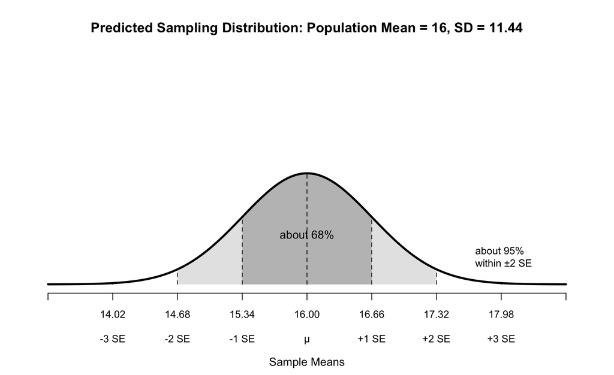

# 3. Audit the simulation code

It is important to audit unfamiliar code before using it. Give AI the [Week 3 Lab Simulation Code.R](https://github.com/craigenders/psych250a/blob/main/labs/Week%203%20Lab%20Simulation%20Code.R) script and use the following prompt exactly as written:

> I will use the R code below to simulate what happens when the mean is computed from many random samples drawn from a population. Inspect the code and provide a high-level conceptual recipe for what it does. Use one bullet for each major step, beginning with the simulation inputs and ending with the numerical and graphical results. Explain the statistical purpose of each step in plain language. Do not explain the code line by line, rewrite the code, suggest stylistic improvements, or discuss individual R commands. Identify any apparent errors that I should inspect.

Using AI’s response as a resource, write a brief passage of approximately three to five sentences explaining the simulation’s goal and major steps to an undergraduate research assistant. Include AI’s response and your explanation in the report.

# 4. Run the simulation

Run the simulation. Evaluate whether the sampling distribution is consistent with your central limit theorem predictions from Question 2. Address the distribution’s shape, center, and standard deviation. Compare the standard deviation of the 100,000 sample means with the standard error you calculated in Question 1.

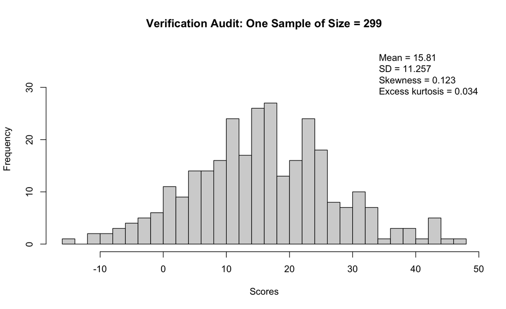

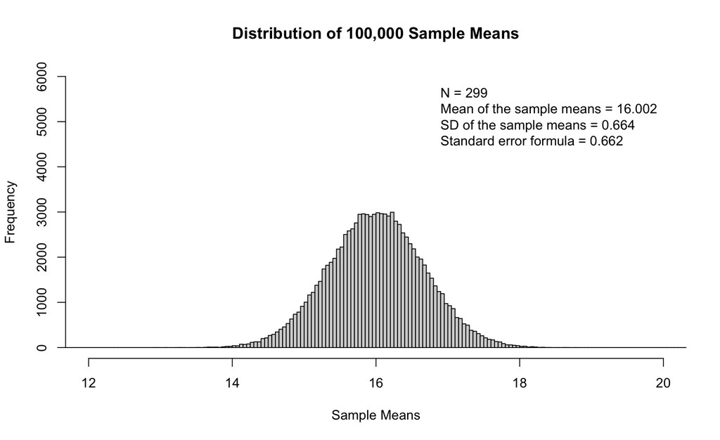

# 5. Evaluate the observed sample mean

The mean of the original sample is 14.85. Suppose the population mean is truly μ = 16. Based on the sampling distribution, how unusual would it be to obtain a sample mean of 14.85 from a random sample of 299 people? Use specific features of the graph and numerical results to support your answer.

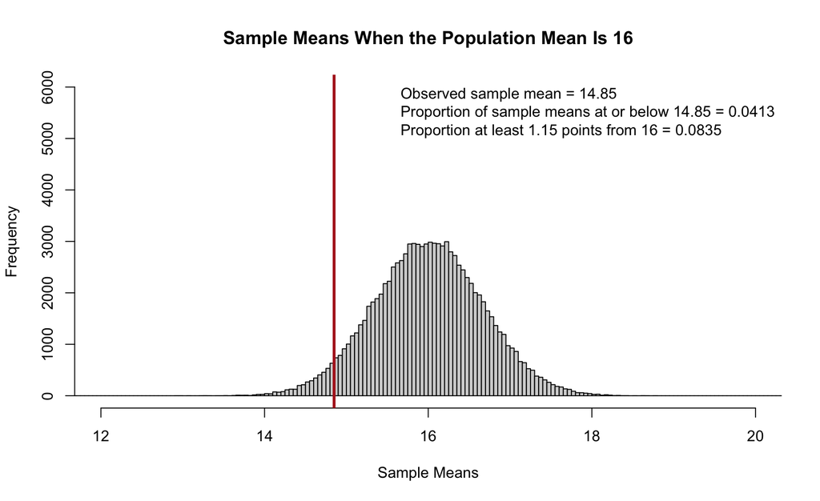

# 6. Predict the effect of a different population mean

The simulation uses an arbitrary population mean of μ = 16. Next, you will run the simulation with a population mean of μ = 13, leaving the population standard deviation and sample size unchanged. Predict what will happen to the center, shape, and spread of the sampling distribution. Then run the simulation code provided in the template for this task, which differs from the Question 4 code only in its population mean.

$$SE = \frac{\sigma}{\sqrt{N}} = \frac{11.44}{\sqrt{299}} =
\frac{11.44}{17.29} = 0.66$$

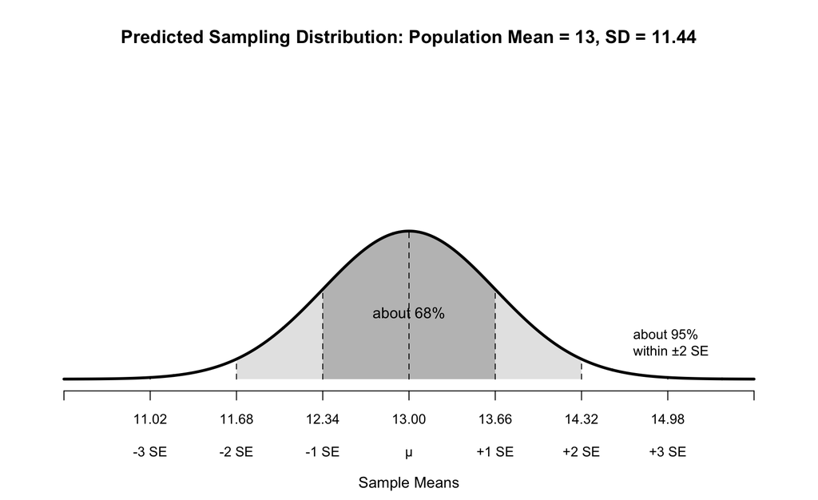

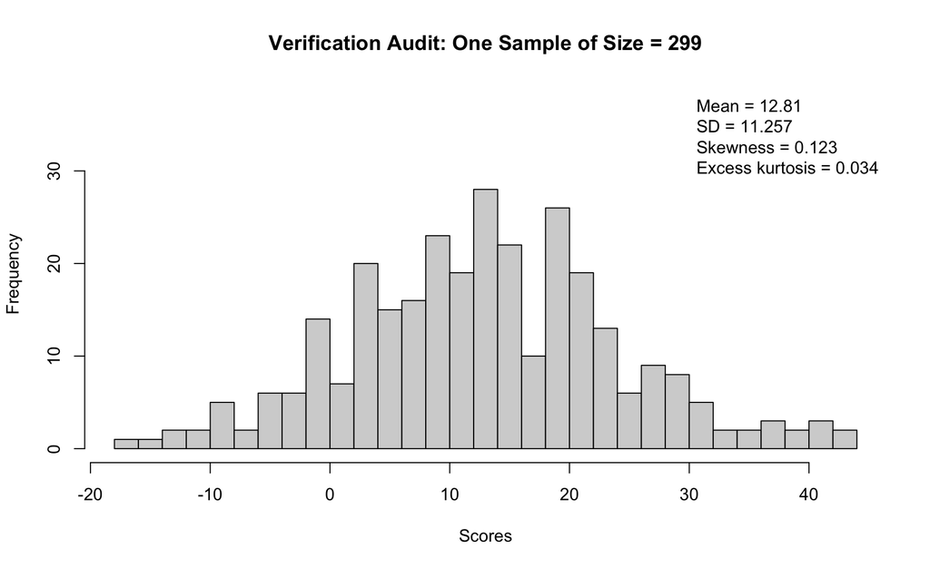

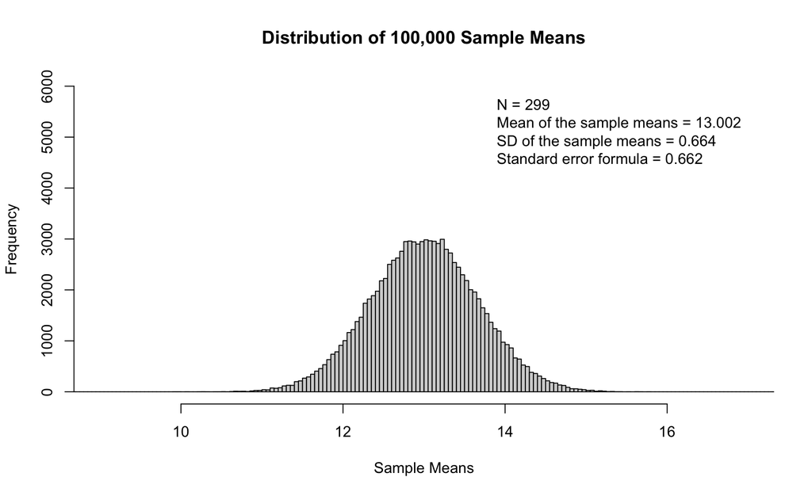

# 7. Explain why the population mean does not matter

The instructions for Question 2 stated that “the choice of population mean does not affect the conclusions about sampling error.” Compare the sampling distribution graphs from Questions 4 and 6, and explain why this statement is true when the goal is to estimate the expected amount of sampling error across many samples.

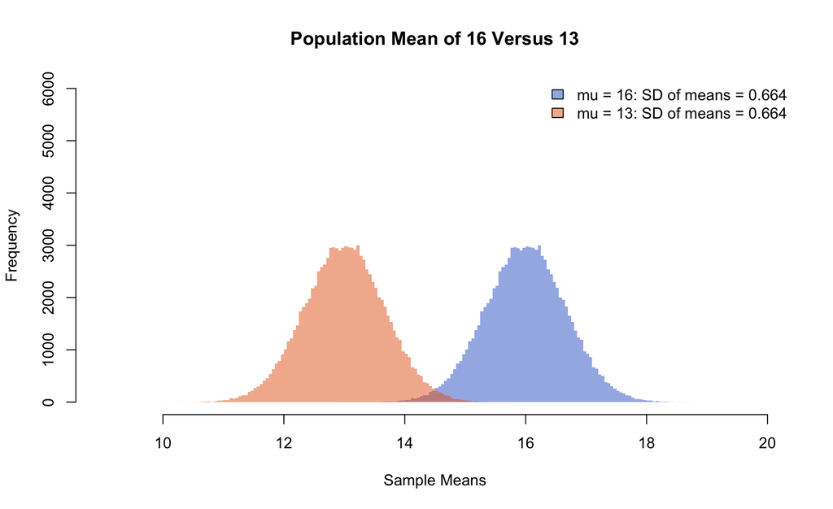

```
     Min.   1st Qu.    Median      Mean   3rd Qu.      Max.
-3.090995 -0.442337  0.003396  0.002428  0.447895  2.752493
```

[output not shown]

# 8. Predict the effect of reduced variability

Next, you will reduce the population standard deviation from 11.44 to 6. This represents a population in which people are more homogeneous in their depressive symptoms. Predict what should happen to the shape, center, and spread of the sampling distribution when the population standard deviation is reduced. Return the population mean to its original value of μ = 16 and leave the sample size unchanged.

$$SE = \frac{\sigma}{\sqrt{N}} = \frac{6}{\sqrt{299}} = \frac{6}{17.29} =
0.35$$

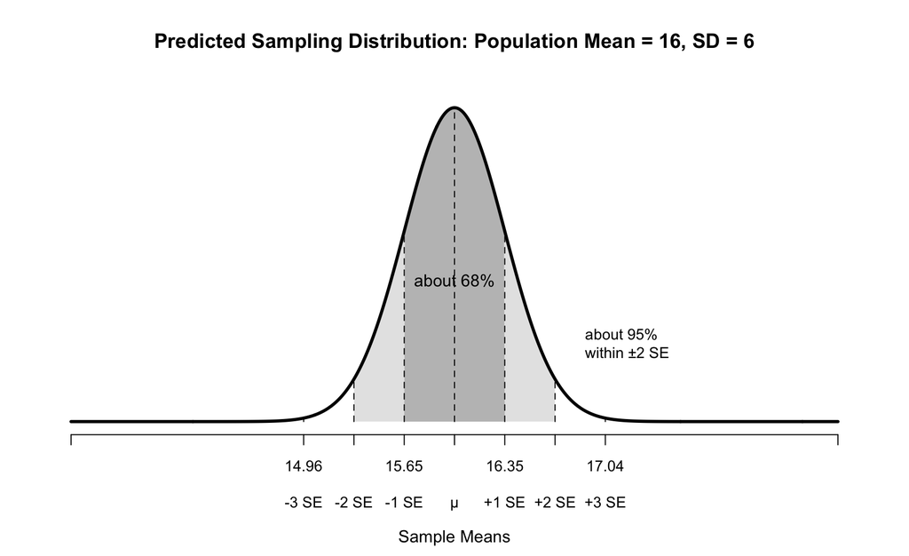

# 9. Consult AI about variability and sampling error

Before running the new simulation, write a prompt asking AI to explain conceptually why increasing or decreasing the variability of individual scores influences the size of the sampling errors. Submit your prompt to AI. Briefly explain whether AI’s response supports or contradicts your prediction from Question 8.

# 10. Reduce the population standard deviation

Modify the simulation code to use the original population mean of μ = 16 and a population standard deviation of 6, and run it again. Leave the sample size unchanged. Compare the new sampling distribution with the original distribution from Question 4. Evaluate whether your predictions about its shape, center, and spread were correct. Calculate the new standard error using the formula and determine whether it agrees with the standard deviation of the 100,000 sample means.

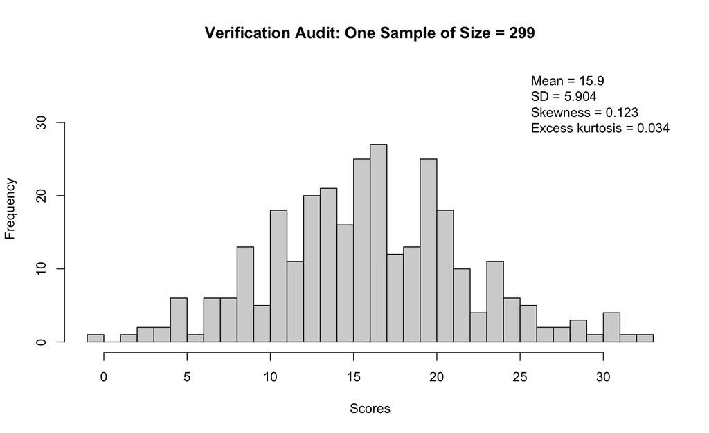

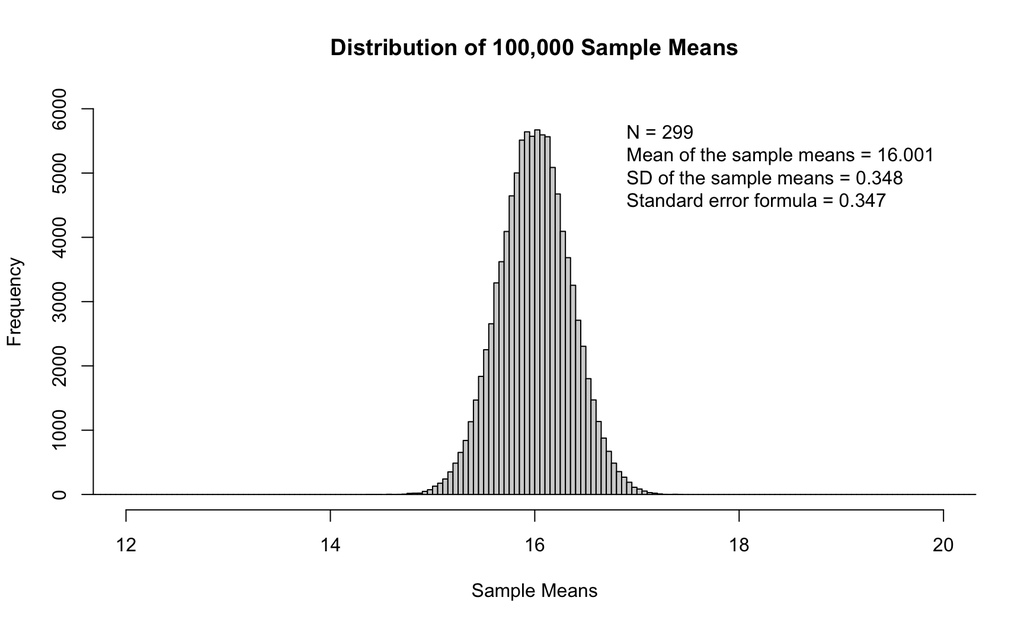

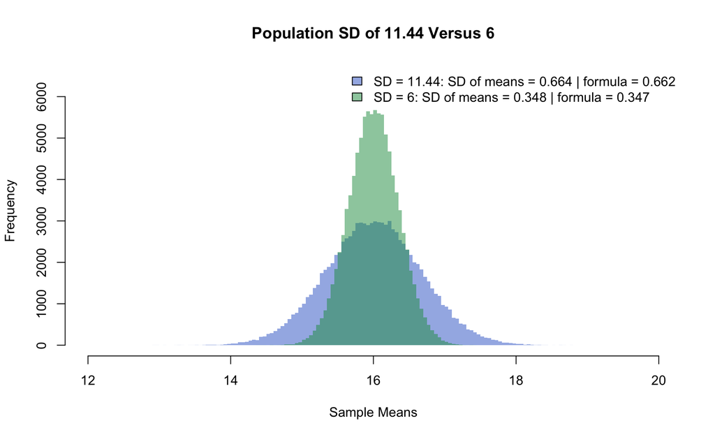